# container: v1.0.0 on CRAN

container

list

R package

The update contains some breaking changes and brings a lot of new features and operators, which markedly improves using containers in both interactive R sessions and code development. Also there is a new class dict.table to support the data.table package.

### What is `container`?

A container can be considered as an enhanced version of base R’s list with a carefully designed set of extract, replace, and remove operations. They enable an easier and safer way to work with list-like data structures in interactive R sessions and in particular when developing critical code.

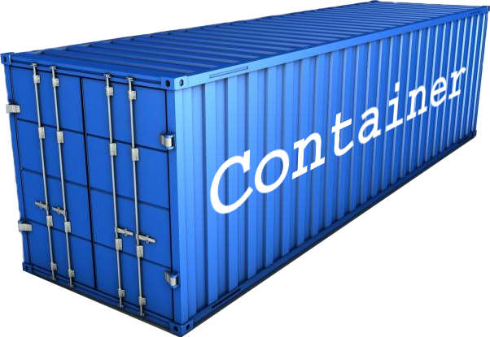

This blog post can only provide a glimpse of all the things you can do with containers so here the focus is on some features suitable for *interactive* R sessions.

### Print

```r
library(container)

co <- container(colors = c("Red", "Green", "Blue"),
                numbers = 1:10,
                data = cars[1:10, ])
```

Let’s start by comparing the print output of container and list (click on the panels below).

### container

```r
print(co)
```

```
[colors = ("Red" "Green" "Blue"), numbers = (1L 2L 3L 4L ...),
 data = <<data.frame(10x2)>>]
```

### list

```r
li = as.list(co)
print(li)
```

```
$colors
[1] "Red"   "Green" "Blue"

$numbers
 [1]  1  2  3  4  5  6  7  8  9 10

$data
   speed dist
1      4    2
2      4   10
3      7    4
4      7   22
5      8   16
6      9   10
7     10   18
8     10   26
9     10   34
10    11   17
```

As you can see the container by default prints very compact. Next, take a look at data extraction.

### Extract

A container provides all familiar extract operations known from base R lists but also some new operations to make life (hopefully) easier. In contrast to base R lists, undefined indices are ignored and thus do not produce `NULL` values.

### container

```r
co[[1]]                  # standard
```

```
[1] "Red"   "Green" "Blue"
```

```r
co[2:3]                  # standard
```

```
[numbers = (1L 2L 3L 4L ...), data = <<data.frame(10x2)>>]
```

```r
co[c(1:2, 5:8)]          # ignore undefined indices
```

```
[colors = ("Red" "Green" "Blue"), numbers = (1L 2L 3L 4L ...)]
```

```r
co[1, 2, 5:8]            # pass any number of indices - same as before
```

```
[colors = ("Red" "Green" "Blue"), numbers = (1L 2L 3L 4L ...)]
```

```r
co[1, "data", 2, "foo"]  # index types can be mixed
```

```
[colors = ("Red" "Green" "Blue"), data = <<data.frame(10x2)>>,
 numbers = (1L 2L 3L 4L ...)]
```

### list

```r
li[[1]]                  # standard
```

```
[1] "Red"   "Green" "Blue"
```

```r
li[2:3]                  # standard
```

```
$numbers
 [1]  1  2  3  4  5  6  7  8  9 10

$data
   speed dist
1      4    2
2      4   10
3      7    4
4      7   22
5      8   16
6      9   10
7     10   18
8     10   26
9     10   34
10    11   17
```

```r
li[c(1:2, 5:8)]          # pad NULLs for undefined indices
```

```
$colors
[1] "Red"   "Green" "Blue"

$numbers
 [1]  1  2  3  4  5  6  7  8  9 10

$<NA>
NULL

$<NA>
NULL

$<NA>
NULL

$<NA>
NULL
```

```r
li[1, 2, 5:8]            # not supported
```

```
Error in li[1, 2, 5:8]: incorrect number of dimensions
```

```r
li[1, "data", 2, "foo"]  # not supported
```

```
Error in li[1, "data", 2, "foo"]: incorrect number of dimensions
```

### Replace

In the same way, a container provides both familiar and new operations for interactive element replacement.

### container

```r
co[2:3] <- NA                                # standard
co
```

```
[colors = ("Red" "Green" "Blue"), numbers = NA, data = NA]
```

```r
co[[1]] <- ""                                # standard
co
```

```
[colors = "", numbers = NA, data = NA]
```

```r
co[["colors"]] <- "red"                      # standard
co
```

```
[colors = "red", numbers = NA, data = NA]
```

```r
co[list("colors", 2)] <- list("blue", 1:4)   # mixed indices
co
```

```
[colors = "blue", numbers = (1L 2L 3L 4L), data = NA]
```

```r
co[[{"blue"}]] <- "green"                    # replace by value
co
```

```
[colors = "green", numbers = (1L 2L 3L 4L), data = NA]
```

```r
co[[{NA}]] <- 0                              # replace by value
co
```

```
[colors = "green", numbers = (1L 2L 3L 4L), data = 0]
```

### list

```r
li[2:3] <- NA                                # standard
li
```

```
$colors
[1] "Red"   "Green" "Blue"

$numbers
[1] NA

$data
[1] NA
```

```r
li[[1]] <- ""                                # standard
li
```

```
$colors
[1] ""

$numbers
[1] NA

$data
[1] NA
```

```r
li[["colors"]] <- "red"                      # standard
co
```

```
[colors = "green", numbers = (1L 2L 3L 4L), data = 0]
```

```r
li[list("colors", 2)] <- list("blue", 1:4)   # not supported
```

```
Error in li[list("colors", 2)] <- list("blue", 1:4): invalid subscript type 'list'
```

```r
#li[[{"blue"}]] <- "green"                   # not supported

#li[[{NA}]] <- 0                             # not supported
```

To see the full official documentation, visit [https://rpahl.github.io/container/](https://rpahl.github.io/container/index.html).